# PDX Crime Map Dashboard

Portland Police Bureau publishes interactive Tableau dashboards with their crime data each month. I used the accompaninying raw data to recreate one. The most helpful feature for a resident IMO is the neighborhood heat map. In order to acheive this recreation, I had to find a geospacial file containing the polygon boundatries of each Portland neighborhood and merge it with the crime data before building the report in Tableau.

The [geospacial file](https://gis-pdx.opendata.arcgis.com/datasets/neighborhoods-regions) was in KML format and required the use of Fiona and Geopandas to read it into a workable format to merge with the PDX crime csv.

I'll outline the steps taken and also provide my Tableau dashboard at the bottom. **Click [here](https://public.tableau.com/views/PortlandCrimeDashboard2019/PDXPoliceDispatches?:display_count=y&publish=yes&:origin=viz_share_link) to skip the code and launch Tableau.**

```python
import pandas as pd
import geopandas as gpd
import fiona
import numpy as np
import matplotlib.pyplot as plt
import seaborn as sns
```

### Reading the KML file with fiona and geopandas

With a quick google search, I found instructions to read KML files by enabling the right driver.

```python
kml_file = "Neighborhood_Boundaries.kml"
```

```python
gpd.io.file.fiona.drvsupport.supported_drivers['KML'] = 'rw' #enable fiona driver
```

```python
geo_data = gpd.read_file(kml_file, driver='KML') #read the KML file into geopandas
```

```python
geo_data.head()
```

|  | Name | Description | geometry |
| --- | --- | --- | --- |
| 0 | LINNTON |  | POLYGON ((-122.8237089611819 45.60615857772244... |
| 1 | FOREST PARK/LINNTON |  | POLYGON ((-122.8231909270121 45.60615651892255... |
| 2 | FOREST PARK |  | POLYGON ((-122.7558129418403 45.51954858251791... |
| 3 | CATHEDRAL PARK |  | POLYGON ((-122.7646055108057 45.58518893125, -... |
| 4 | UNIVERSITY PARK |  | POLYGON ((-122.7385520535061 45.58394808045919... |

```python
geo_data.shape
```

```
(131, 3)
```

### Loading the PDX crime data

Here the PDX crime data is read into a Pandas dataframe. After reviewing the data types and checking for outliers, I have to decide how to merge the two files.

```python
crime_data = pd.read_csv('/Users/mac/Downloads/CAD-OCT-2019.csv')
```

```python
crime_data.info()
```

```
<class 'pandas.core.frame.DataFrame'>
RangeIndex: 144430 entries, 0 to 144429
Data columns (total 14 columns):
Address              144430 non-null object
CallNumber           144430 non-null int64
FinalCallCategory    144430 non-null object
FinalCallGroup       144430 non-null object
Neighborhood         141394 non-null object
OpenDataLat          143283 non-null float64
OpenDataLon          143283 non-null float64
OpenDataX            143283 non-null float64
OpenDataY            143283 non-null float64
Priority             144430 non-null object
ReportMonthYear      144430 non-null object
ResponseTime_sec     137021 non-null object
TimeInQueue_sec      143966 non-null object
TravelTime_sec       137431 non-null object
dtypes: float64(4), int64(1), object(9)
memory usage: 15.4+ MB
```

```python
crime_data.head()
```

|  | Address | CallNumber | FinalCallCategory | FinalCallGroup | Neighborhood | OpenDataLat | OpenDataLon | OpenDataX | OpenDataY | Priority | ReportMonthYear | ResponseTime_sec | TimeInQueue_sec | TravelTime_sec |
| --- | --- | --- | --- | --- | --- | --- | --- | --- | --- | --- | --- | --- | --- | --- |
| 0 | 0 BLOCK OF BURNSIDE BRG | 2698722952 | Welfare Check | Disorder | Old Town/Chinatown | 45.523046 | -122.669931 | 7646019.0 | 684258.0 | High | April 2019 | 253 | 48 | 205 |
| 1 | 0 BLOCK OF BURNSIDE BRG | 2715998924 | Theft | Crime | Old Town/Chinatown | 45.523046 | -122.669931 | 7646019.0 | 684258.0 | Medium | May 2019 | 548 | 100 | 448 |
| 2 | 0 BLOCK OF CONCOURSE C PIA | 2668055712 | Follow Up | Other | NaN | 45.589270 | -122.597122 | 7665300.0 | 707903.0 | High | January 2019 | 1,770 | 9 | 1,761 |
| 3 | 0 BLOCK OF HAWTHORNE BRG | 2717552941 | Suspicious | Disorder | NaN | 45.512944 | -122.669655 | 7645991.0 | 680574.0 | High | June 2019 | 109 | 15 | 94 |
| 4 | 0 BLOCK OF KERR PKWY | 2716354841 | Assist | Assist | NaN | 45.434325 | -122.719464 | 7632440.0 | 652267.0 | High | May 2019 | 305 | 85 | 220 |

### Can they merge yet?

Before I merge these, I need to determine which shared column can link them. It looks like crime_data.Neighbohood and police_data.Name contain the names of each Portland neighborhood. Checking for consistency in naming convention...

```python
crime_data.Neighborhood.sort_values().unique()
```

```
array(['Alameda', 'Arbor Lodge', 'Ardenwald', 'Argay',
       'Arlington Heights', 'Arnold Creek', 'Ashcreek',
       'Beaumont-Wilshire', 'Boise', 'Brentwood-Darlington', 'Bridgeton',
       'Bridlemile', 'Brooklyn', 'Buckman East', 'Buckman West',
       'Cathedral Park', 'Centennial', 'Collins View', 'Concordia',
       'Creston-Kenilworth', 'Crestwood', 'Cully', 'Downtown',
       'East Columbia', 'Eastmoreland', 'Eliot', 'Far Southwest',
       'Forest Park', 'Foster-Powell', 'Glenfair', 'Goose Hollow',
       'Grant Park', 'Hayden Island', 'Hayhurst', 'Hazelwood',
       'Healy Heights', 'Hillsdale', 'Hillside', 'Hollywood', 'Homestead',
       'Hosford-Abernethy', 'Humboldt', 'Irvington', 'Kenton', 'Kerns',
       'King', 'Laurelhurst', 'Lents', 'Linnton', 'Lloyd',
       'Madison South', 'Maplewood', 'Markham', 'Marshall Park',
       'Mill Park', 'Montavilla', 'Mt Scott-Arleta', 'Mt Tabor',
       'Multnomah', 'North Tabor', 'Northwest', 'Northwest Heights',
       'Northwest Industrial', 'Old Town/Chinatown', 'Overlook',
       'Parkrose', 'Parkrose Heights', 'Pearl', 'Piedmont',
       'Pleasant Valley', 'Portsmouth', 'Powellhurst-Gilbert', 'Reed',
       'Richmond', 'Rose City Park', 'Roseway', 'Russell', 'Sabin',
       'Sellwood-Moreland', 'South Burlingame', 'South Portland',
       'South Tabor', 'Southwest Hills', 'St Johns', "Sullivan's Gulch",
       'Sumner', 'Sunderland', 'Sunnyside', 'Sylvan-Highlands',
       'University Park', 'Vernon', 'West Portland Park', 'Wilkes',
       'Woodland Park', 'Woodlawn', 'Woodstock', nan], dtype=object)
```

```python
len(crime_data.Neighborhood.unique())
```

```
97
```

```python
geo_data.Name.sort_values().unique()
```

```
array(['ALAMEDA', 'ALAMEDA/BEAUMONT-WILSHIRE',
       'ALAMEDA/IRVINGTON COMMUNITY ASSN.', 'ARBOR LODGE',
       'ARDENWALD-JOHNSON CREEK', 'ARDENWALD-JOHNSON CREEK/WOODSTOCK',
       'ARGAY TERRACE', 'ARGAY/WILKES COMMUNITY GROUP',
       'ARLINGTON HEIGHTS', 'ARLINGTON HEIGHTS/SYLVAN-HIGHLANDS',
       'ARNOLD CREEK', 'ASHCREEK', 'ASHCREEK/CRESTWOOD',
       'BEAUMONT-WILSHIRE', 'BOISE', 'BOISE/ELIOT',
       'BRENTWOOD-DARLINGTON', 'BRIDGETON', 'BRIDLEMILE',
       'BRIDLEMILE/SOUTHWEST HILLS RESIDENTIAL LEAGUE',
       'BROOKLYN ACTION CORPS', 'BUCKMAN COMMUNITY ASSOCIATION',
       'CATHEDRAL PARK', 'CENTENNIAL COMMUNITY ASSN./PLEASANT VALLEY',
       'CENTENNIAL COMMUNITY ASSOCIATION', 'COLLINS VIEW', 'CONCORDIA',
       'CRESTON-KENILWORTH', 'CRESTWOOD',
       'CULLY ASSOCIATION OF NEIGHBORS', 'EAST COLUMBIA', 'EASTMORELAND',
       'EASTMORELAND/ARDENWALD-JOHNSON CREEK', 'EASTMORELAND/REED',
       'ELIOT', 'FAR SOUTHWEST', 'FOREST PARK', 'FOREST PARK/LINNTON',
       'FOREST PARK/NORTHWEST DISTRICT ASSOCIATION', 'FOSTER-POWELL',
       'GLENFAIR', 'GOOSE HOLLOW FOOTHILLS LEAGUE',
       'GOOSE HOLLOW FOOTHILLS LEAGUE/SOUTHWEST HILLS RESIDENTIAL LEAGUE',
       'GRANT PARK', 'GRANT PARK/HOLLYWOOD',
       'HAYDEN ISLAND NEIGHBORHOOD NETWORK', 'HAYHURST', 'HAZELWOOD',
       'HAZELWOOD/MILL PARK',
       'HEALY HEIGHTS/SOUTHWEST HILLS RESIDENTIAL LEAGUE', 'HILLSDALE',
       'HILLSIDE', 'HILLSIDE/NORTHWEST DISTRICT ASSN.', 'HOLLYWOOD',
       'HOMESTEAD', 'HOSFORD-ABERNETHY NEIGHBORHOOD DISTRICT ASSN.',
       'HUMBOLDT', 'IRVINGTON COMMUNITY ASSOCIATION', 'KENTON', 'KERNS',
       'KING', 'LAURELHURST', 'LENTS', 'LENTS/POWELLHURST-GILBERT',
       'LINNTON', "LLOYD DISTRICT COMMUNITY ASSN./SULLIVAN'S GULCH",
       'LLOYD DISTRICT COMMUNITY ASSOCIATION', 'MADISON SOUTH',
       'MAPLEWOOD', 'MARKHAM', 'MARSHALL PARK', 'MC UNCLAIMED #11',
       'MC UNCLAIMED #13', 'MC UNCLAIMED #14', 'MC UNCLAIMED #5',
       'MILL PARK', 'MONTAVILLA', 'MT. SCOTT-ARLETA', 'MT. TABOR',
       'MULTNOMAH', 'NORTH TABOR', 'NORTHWEST DISTRICT ASSOCIATION',
       'NORTHWEST HEIGHTS', 'OLD TOWN COMMUNITY ASSOCIATION', 'OVERLOOK',
       'PARKROSE', 'PARKROSE HEIGHTS ASSOCIATION OF NEIGHBORS',
       'PEARL DISTRICT', 'PIEDMONT', 'PLEASANT VALLEY',
       'PLEASANT VALLEY/POWELLHURST-GILBERT', 'PORTLAND DOWNTOWN',
       'PORTSMOUTH', 'POWELLHURST-GILBERT', 'REED', 'RICHMOND',
       'ROSE CITY PARK', 'ROSEWAY', 'ROSEWAY/MADISON SOUTH', 'RUSSELL',
       'SABIN COMMUNITY ASSN./IRVINGTON COMMUNITY ASSN.',
       'SABIN COMMUNITY ASSOCIATION',
       'SELLWOOD-MORELAND IMPROVEMENT LEAGUE', 'SOUTH BURLINGAME',
       'SOUTH PORTLAND', 'SOUTH TABOR',
       'SOUTHWEST HILLS RESIDENTIAL LEAGUE', 'ST. JOHNS',
       "SULLIVAN'S GULCH", "SULLIVAN'S GULCH/GRANT PARK",
       'SUMNER ASSOCIATION OF NEIGHBORS',
       'SUNDERLAND ASSOCIATION OF NEIGHBORS', 'SUNNYSIDE',
       'SYLVAN-HIGHLANDS',
       'SYLVAN-HIGHLANDS/SOUTHWEST HILLS RESIDENTIAL LEAGUE',
       'UNIVERSITY PARK', 'VERNON', 'WEST PORTLAND PARK',
       'WILKES COMMUNITY GROUP', 'WOODLAND PARK', 'WOODLAWN', 'WOODSTOCK'],
      dtype=object)
```

```python
len(geo_data.Name.sort_values().unique())
```

```
122
```

### Issues

There are 25 more neighborhood names or variations on **geo_data** than the **crime_data** list. Not only are some of them intersections of two different neighborhoods, several have different names all together. I can't trust they can be combined correctly this way.

### Spatial Join to the rescue

Luckily there are Latitude and Longitude coordinates for each entry in the **crime_data** file. I'll check for NaN values and see if it's worth converting the coordinates to a geometry **Point**. From there the file can be combined with **geo_data** geometry wherever the **Point** is inside the bounds of the **Polygon** data.

```python
len(crime_data[crime_data.OpenDataLon.isna()])
```

```
1147
```

```python
neighborhood_lon_na = (crime_data.Neighborhood.isna()) & (crime_data.OpenDataLon.isna())
```

```python
crime_data[neighborhood_lon_na].sort_values(by='Address')
```

|  | Address | CallNumber | FinalCallCategory | FinalCallGroup | Neighborhood | OpenDataLat | OpenDataLon | OpenDataX | OpenDataY | Priority | ReportMonthYear | ResponseTime_sec | TimeInQueue_sec | TravelTime_sec |
| --- | --- | --- | --- | --- | --- | --- | --- | --- | --- | --- | --- | --- | --- | --- |
| 10341 | 400 BLOCK OF NE MOTHER JOSEPH PL | 2693126216 | Follow Up | Other | NaN | NaN | NaN | NaN | NaN | Low | March 2019 | 9,905 | 8,462 | 1,443 |
| 143159 | UNKNOWN ADDRESS | 2713977442 | Disturbance | Disorder | NaN | NaN | NaN | NaN | NaN | High | May 2019 | 630 | 76 | 554 |
| 143160 | UNKNOWN ADDRESS | 2713984982 | Welfare Check | Disorder | NaN | NaN | NaN | NaN | NaN | High | May 2019 | 1,605 | 146 | 1,459 |
| 143161 | UNKNOWN ADDRESS | 2714008954 | Assist | Assist | NaN | NaN | NaN | NaN | NaN | Medium | May 2019 | NaN | 62 | NaN |
| 143162 | UNKNOWN ADDRESS | 2714050914 | Area/Premise Check | Disorder | NaN | NaN | NaN | NaN | NaN | Medium | May 2019 | 766 | 36 | 730 |
| 143163 | UNKNOWN ADDRESS | 2714177414 | Collision | Traffic | NaN | NaN | NaN | NaN | NaN | Medium | May 2019 | 136 | 86 | 50 |
| 143164 | UNKNOWN ADDRESS | 2714209234 | Collision | Traffic | NaN | NaN | NaN | NaN | NaN | Medium | May 2019 | 671 | 119 | 552 |
| 143165 | UNKNOWN ADDRESS | 2714248714 | Hazard | Traffic | NaN | NaN | NaN | NaN | NaN | Medium | May 2019 | 495 | 212 | 283 |
| 143166 | UNKNOWN ADDRESS | 2714315453 | Warrant | Assist | NaN | NaN | NaN | NaN | NaN | High | May 2019 | 236 | 48 | 188 |
| 143167 | UNKNOWN ADDRESS | 2714358114 | Hazard | Traffic | NaN | NaN | NaN | NaN | NaN | Medium | May 2019 | 898 | 38 | 860 |
| 143168 | UNKNOWN ADDRESS | 2714492924 | Welfare Check | Disorder | NaN | NaN | NaN | NaN | NaN | Medium | May 2019 | 502 | 122 | 380 |
| 143169 | UNKNOWN ADDRESS | 2714578632 | Unwanted Person | Disorder | NaN | NaN | NaN | NaN | NaN | High | May 2019 | 485 | 17 | 468 |
| 143170 | UNKNOWN ADDRESS | 2714686214 | Assist | Assist | NaN | NaN | NaN | NaN | NaN | Medium | May 2019 | 1,917 | 2 | 1,915 |
| 143171 | UNKNOWN ADDRESS | 2714741114 | Hazard | Traffic | NaN | NaN | NaN | NaN | NaN | Medium | May 2019 | 353 | 43 | 310 |
| 143172 | UNKNOWN ADDRESS | 2714800424 | Area/Premise Check | Disorder | NaN | NaN | NaN | NaN | NaN | Medium | May 2019 | 163 | 40 | 123 |
| 143173 | UNKNOWN ADDRESS | 2714822222 | Welfare Check | Disorder | NaN | NaN | NaN | NaN | NaN | High | May 2019 | NaN | 33 | NaN |
| 143174 | UNKNOWN ADDRESS | 2714848952 | Welfare Check | Disorder | NaN | NaN | NaN | NaN | NaN | High | May 2019 | 322 | 10 | 312 |
| 143175 | UNKNOWN ADDRESS | 2714906042 | Disturbance | Disorder | NaN | NaN | NaN | NaN | NaN | High | May 2019 | 185 | 60 | 125 |
| 143189 | UNKNOWN ADDRESS | 2715689532 | Assist | Assist | NaN | NaN | NaN | NaN | NaN | High | May 2019 | 271 | 51 | 220 |
| 143188 | UNKNOWN ADDRESS | 2715604512 | Welfare Check | Disorder | NaN | NaN | NaN | NaN | NaN | High | May 2019 | 17 | 17 | 0 |
| 143187 | UNKNOWN ADDRESS | 2715578934 | Assist | Assist | NaN | NaN | NaN | NaN | NaN | Medium | May 2019 | 634 | 36 | 598 |
| 143186 | UNKNOWN ADDRESS | 2715501012 | Welfare Check | Disorder | NaN | NaN | NaN | NaN | NaN | High | May 2019 | 20 | 20 | 0 |
| 143185 | UNKNOWN ADDRESS | 2715497014 | Welfare Check | Disorder | NaN | NaN | NaN | NaN | NaN | Medium | May 2019 | 253 | 100 | 153 |
| 143184 | UNKNOWN ADDRESS | 2715483012 | Welfare Check | Disorder | NaN | NaN | NaN | NaN | NaN | High | May 2019 | 67 | 67 | 0 |
| 143158 | UNKNOWN ADDRESS | 2713842422 | Welfare Check | Disorder | NaN | NaN | NaN | NaN | NaN | High | May 2019 | 361 | 14 | 347 |
| 143183 | UNKNOWN ADDRESS | 2715397332 | Welfare Check | Disorder | NaN | NaN | NaN | NaN | NaN | High | May 2019 | 544 | 111 | 433 |
| 143181 | UNKNOWN ADDRESS | 2715100526 | Unwanted Person | Disorder | NaN | NaN | NaN | NaN | NaN | Low | May 2019 | 1,316 | 636 | 680 |
| 143180 | UNKNOWN ADDRESS | 2715083632 | Disturbance | Disorder | NaN | NaN | NaN | NaN | NaN | High | May 2019 | 706 | 46 | 660 |
| 143179 | UNKNOWN ADDRESS | 2715049914 | Animal Problem | Disorder | NaN | NaN | NaN | NaN | NaN | Medium | May 2019 | 1,021 | 1,021 | 0 |
| 143178 | UNKNOWN ADDRESS | 2714996314 | Collision | Traffic | NaN | NaN | NaN | NaN | NaN | Medium | May 2019 | 673 | 66 | 607 |
| ... | ... | ... | ... | ... | ... | ... | ... | ... | ... | ... | ... | ... | ... | ... |
| 142774 | UNKNOWN ADDRESS | 2689620117 | Follow Up | Other | NaN | NaN | NaN | NaN | NaN | Low | March 2019 | NaN | 1,263 | NaN |
| 142773 | UNKNOWN ADDRESS | 2689618633 | Theft | Crime | NaN | NaN | NaN | NaN | NaN | High | March 2019 | 493 | 139 | 354 |
| 142779 | UNKNOWN ADDRESS | 2690179942 | Disturbance | Disorder | NaN | NaN | NaN | NaN | NaN | High | March 2019 | 366 | 59 | 307 |
| 142772 | UNKNOWN ADDRESS | 2689532933 | Suspicious | Disorder | NaN | NaN | NaN | NaN | NaN | High | March 2019 | 486 | 47 | 439 |
| 142770 | UNKNOWN ADDRESS | 2689379014 | Suspicious | Disorder | NaN | NaN | NaN | NaN | NaN | Medium | March 2019 | 2,114 | 371 | 1,743 |
| 142769 | UNKNOWN ADDRESS | 2689378324 | Collision | Traffic | NaN | NaN | NaN | NaN | NaN | Medium | March 2019 | 275 | 19 | 256 |
| 142768 | UNKNOWN ADDRESS | 2689282014 | Suspicious | Disorder | NaN | NaN | NaN | NaN | NaN | Medium | March 2019 | 530 | 274 | 256 |
| 142767 | UNKNOWN ADDRESS | 2689088532 | Welfare Check | Disorder | NaN | NaN | NaN | NaN | NaN | High | March 2019 | 130 | 36 | 94 |
| 142766 | UNKNOWN ADDRESS | 2688980444 | Assist | Assist | NaN | NaN | NaN | NaN | NaN | Medium | March 2019 | 942 | 78 | 864 |
| 142765 | UNKNOWN ADDRESS | 2688721222 | Welfare Check | Disorder | NaN | NaN | NaN | NaN | NaN | High | March 2019 | 327 | 19 | 308 |
| 142771 | UNKNOWN ADDRESS | 2689444233 | Assist | Assist | NaN | NaN | NaN | NaN | NaN | High | March 2019 | 233 | 84 | 149 |
| 142798 | UNKNOWN ADDRESS | 2691499643 | Assist | Assist | NaN | NaN | NaN | NaN | NaN | High | March 2019 | NaN | 22 | NaN |
| 142780 | UNKNOWN ADDRESS | 2690314514 | Collision | Traffic | NaN | NaN | NaN | NaN | NaN | Medium | March 2019 | 491 | 38 | 453 |
| 142782 | UNKNOWN ADDRESS | 2690407732 | Welfare Check | Disorder | NaN | NaN | NaN | NaN | NaN | High | March 2019 | 355 | 32 | 323 |
| 142796 | UNKNOWN ADDRESS | 2691412842 | Disturbance | Disorder | NaN | NaN | NaN | NaN | NaN | High | March 2019 | 609 | 146 | 463 |
| 142795 | UNKNOWN ADDRESS | 2691190923 | Disorder | Disorder | NaN | NaN | NaN | NaN | NaN | High | March 2019 | 548 | 110 | 438 |
| 142794 | UNKNOWN ADDRESS | 2691121462 | Disturbance | Disorder | NaN | NaN | NaN | NaN | NaN | High | March 2019 | 505 | 25 | 480 |
| 142793 | UNKNOWN ADDRESS | 2690938123 | Assist | Assist | NaN | NaN | NaN | NaN | NaN | High | March 2019 | 568 | 142 | 426 |
| 142792 | UNKNOWN ADDRESS | 2690934614 | Hazard | Traffic | NaN | NaN | NaN | NaN | NaN | Medium | March 2019 | 481 | 44 | 437 |
| 142791 | UNKNOWN ADDRESS | 2690771832 | Disturbance | Disorder | NaN | NaN | NaN | NaN | NaN | High | March 2019 | 242 | 68 | 174 |
| 142781 | UNKNOWN ADDRESS | 2690344214 | Suspicious | Disorder | NaN | NaN | NaN | NaN | NaN | Medium | March 2019 | 1,197 | 1,029 | 168 |
| 142790 | UNKNOWN ADDRESS | 2690767824 | Welfare Check | Disorder | NaN | NaN | NaN | NaN | NaN | Medium | March 2019 | 680 | 72 | 608 |
| 142788 | UNKNOWN ADDRESS | 2690646614 | Assist | Assist | NaN | NaN | NaN | NaN | NaN | Medium | March 2019 | 1,178 | 664 | 514 |
| 142787 | UNKNOWN ADDRESS | 2690607414 | Assist | Assist | NaN | NaN | NaN | NaN | NaN | Medium | March 2019 | 342 | 342 | 0 |
| 142786 | UNKNOWN ADDRESS | 2690595812 | Welfare Check | Disorder | NaN | NaN | NaN | NaN | NaN | High | March 2019 | 33 | 33 | 0 |
| 142785 | UNKNOWN ADDRESS | 2690544726 | Theft | Crime | NaN | NaN | NaN | NaN | NaN | Low | March 2019 | 185 | 185 | 0 |
| 142784 | UNKNOWN ADDRESS | 2690517314 | Theft | Crime | NaN | NaN | NaN | NaN | NaN | Medium | March 2019 | 718 | 142 | 576 |
| 142783 | UNKNOWN ADDRESS | 2690454831 | Disturbance | Disorder | NaN | NaN | NaN | NaN | NaN | High | March 2019 | 272 | 18 | 254 |
| 142789 | UNKNOWN ADDRESS | 2690749324 | Collision | Traffic | NaN | NaN | NaN | NaN | NaN | Medium | March 2019 | 650 | 287 | 363 |
| 143547 | UNKNOWN ADDRESS | 2739127516 | Welfare Check | Disorder | NaN | NaN | NaN | NaN | NaN | Low | July 2019 | 3,648 | 3,285 | 363 |

1140 rows × 14 columns

```python
crime_data[crime_data['Address'] == '400 BLOCK OF NE MOTHER JOSEPH PL'] #checking to see if the address matches any other record to pull Neighborhood name
```

|  | Address | CallNumber | FinalCallCategory | FinalCallGroup | Neighborhood | OpenDataLat | OpenDataLon | OpenDataX | OpenDataY | Priority | ReportMonthYear | ResponseTime_sec | TimeInQueue_sec | TravelTime_sec |
| --- | --- | --- | --- | --- | --- | --- | --- | --- | --- | --- | --- | --- | --- | --- |
| 10341 | 400 BLOCK OF NE MOTHER JOSEPH PL | 2693126216 | Follow Up | Other | NaN | NaN | NaN | NaN | NaN | Low | March 2019 | 9,905 | 8,462 | 1,443 |

```python
unique_addr= crime_data[neighborhood_lon_na].sort_values(by='Address')
```

```python
len(unique_addr.Address.unique())
```

```
2
```

So there are 1,147 rows with missing lat/lon coordinates and 1,140 of them are even missing the Neighborhood name. Only one of them has an actual address and the rest are listed as 'UNKNOWN ADDRESS.'

Googling **400 BLOCK OF NE MOTHER JOSEPH PL** results in what appears to be a hospital in Vancouver, WA. Also listed as a "Follow Up," perhaps this police response was a visit to a patient or hospital employee involved in an ongoing local matter?

[figure not shown]

### Consensus

I'll run the spatial join and manually insert the Polygon data into the 7 rows with a Neighborhood name but no lat/lon coordinates. The other 1,140 are bad data for the purpose of linking them to a geo location. They *should* stick around because we can still use them towards the total call volume for each month they were recorded in.

### Step one of Spatial Join:

#### Convert coordinates to Point

I'll need to combine the **OpenDataLat** and **OpenDataLon** columns into a new column and convert the entire pandas dataframe into a **GeoDataFrame** that can recognize the **Point** data.

```python
import shapely.speedups
```

```python
shapely.speedups.enable()
```

```python
from shapely.geometry import Point
```

```python
from geopandas import GeoDataFrame
```

```python
geometry = [Point(xy) for xy in zip(crime_data.OpenDataLon, crime_data.OpenDataLat)]
crs = {'init': 'epsg:4326'}
crime_gdf = GeoDataFrame(crime_data, crs=crs, geometry=geometry)
```

```python
crime_gdf.info() #Noting the new 'geometry' column has been added
```

```
<class 'geopandas.geodataframe.GeoDataFrame'>
RangeIndex: 144430 entries, 0 to 144429
Data columns (total 15 columns):
Address              144430 non-null object
CallNumber           144430 non-null int64
FinalCallCategory    144430 non-null object
FinalCallGroup       144430 non-null object
Neighborhood         141394 non-null object
OpenDataLat          143283 non-null float64
OpenDataLon          143283 non-null float64
OpenDataX            143283 non-null float64
OpenDataY            143283 non-null float64
Priority             144430 non-null object
ReportMonthYear      144430 non-null object
ResponseTime_sec     137021 non-null object
TimeInQueue_sec      143966 non-null object
TravelTime_sec       137431 non-null object
geometry             144430 non-null object
dtypes: float64(4), int64(1), object(10)
memory usage: 16.5+ MB
```

```python
crime_gdf.head() #Checking for output in the new column
```

|  | Address | CallNumber | FinalCallCategory | FinalCallGroup | Neighborhood | OpenDataLat | OpenDataLon | OpenDataX | OpenDataY | Priority | ReportMonthYear | ResponseTime_sec | TimeInQueue_sec | TravelTime_sec | geometry |
| --- | --- | --- | --- | --- | --- | --- | --- | --- | --- | --- | --- | --- | --- | --- | --- |
| 0 | 0 BLOCK OF BURNSIDE BRG | 2698722952 | Welfare Check | Disorder | Old Town/Chinatown | 45.523046 | -122.669931 | 7646019.0 | 684258.0 | High | April 2019 | 253 | 48 | 205 | POINT (-122.669931276 45.52304646100001) |
| 1 | 0 BLOCK OF BURNSIDE BRG | 2715998924 | Theft | Crime | Old Town/Chinatown | 45.523046 | -122.669931 | 7646019.0 | 684258.0 | Medium | May 2019 | 548 | 100 | 448 | POINT (-122.669931276 45.52304646100001) |
| 2 | 0 BLOCK OF CONCOURSE C PIA | 2668055712 | Follow Up | Other | NaN | 45.589270 | -122.597122 | 7665300.0 | 707903.0 | High | January 2019 | 1,770 | 9 | 1,761 | POINT (-122.597122039 45.589270088) |
| 3 | 0 BLOCK OF HAWTHORNE BRG | 2717552941 | Suspicious | Disorder | NaN | 45.512944 | -122.669655 | 7645991.0 | 680574.0 | High | June 2019 | 109 | 15 | 94 | POINT (-122.669654517 45.51294401600001) |
| 4 | 0 BLOCK OF KERR PKWY | 2716354841 | Assist | Assist | NaN | 45.434325 | -122.719464 | 7632440.0 | 652267.0 | High | May 2019 | 305 | 85 | 220 | POINT (-122.719464137 45.43432527) |

### Finally, the Spatial Join...

Doing a left join will keep the **geometry** column of the GeoDataFrame containg Neighborhood Polygon info.

```python
geo_crime_data = gpd.sjoin(geo_data,crime_gdf, how="left", op="contains")
```

```python
geo_crime_data.info()
```

```
<class 'geopandas.geodataframe.GeoDataFrame'>
Int64Index: 141780 entries, 0 to 130
Data columns (total 18 columns):
Name                 141780 non-null object
Description          141780 non-null object
geometry             141780 non-null object
index_right          141773 non-null float64
Address              141773 non-null object
CallNumber           141773 non-null float64
FinalCallCategory    141773 non-null object
FinalCallGroup       141773 non-null object
Neighborhood         141127 non-null object
OpenDataLat          141773 non-null float64
OpenDataLon          141773 non-null float64
OpenDataX            141773 non-null float64
OpenDataY            141773 non-null float64
Priority             141773 non-null object
ReportMonthYear      141773 non-null object
ResponseTime_sec     134565 non-null object
TimeInQueue_sec      141316 non-null object
TravelTime_sec       134969 non-null object
dtypes: float64(6), object(12)
memory usage: 20.6+ MB
```

### Those that did not join

Our new GeoDataFrame contains 141,780 records down from 144,430 - so missing 2,650 rows. I believe the **CallNumber** column should have a unique value for each entry so I'll compare crime_gdf.CallNumber with geo_crime_data.CallNumber to see if we can merge in the missing rows.

```python
#converting col to same data type as crime_gdf.CallNumber
geo_crime_data['CallNumber'] = geo_crime_data['CallNumber'].values.astype(np.int64)
```

```python
len(geo_crime_data.CallNumber.unique())
```

```
141774
```

```python
len(crime_gdf.CallNumber.unique())
```

```
144430
```

```python
len(crime_gdf[crime_gdf.CallNumber.isin(geo_crime_data.CallNumber)==False])
```

```
2657
```

So 2,657 rows. Curious where the additional 7 came from...

```python
geo_crime_data.sort_values(by='CallNumber').head(10)
```

|  | Name | Description | geometry | index_right | Address | CallNumber | FinalCallCategory | FinalCallGroup | Neighborhood | OpenDataLat | OpenDataLon | OpenDataX | OpenDataY | Priority | ReportMonthYear | ResponseTime_sec | TimeInQueue_sec | TravelTime_sec |
| --- | --- | --- | --- | --- | --- | --- | --- | --- | --- | --- | --- | --- | --- | --- | --- | --- | --- | --- |
| 123 | MC UNCLAIMED #13 |  | POLYGON ((-122.66865051475 45.43632417626866, ... | NaN | NaN | -9223372036854775808 | NaN | NaN | NaN | NaN | NaN | NaN | NaN | NaN | NaN | NaN | NaN | NaN |
| 122 | MC UNCLAIMED #13 |  | POLYGON ((-122.6705672321054 45.4439249108848,... | NaN | NaN | -9223372036854775808 | NaN | NaN | NaN | NaN | NaN | NaN | NaN | NaN | NaN | NaN | NaN | NaN |
| 121 | ASHCREEK/CRESTWOOD |  | POLYGON ((-122.7274849493429 45.45841483015463... | NaN | NaN | -9223372036854775808 | NaN | NaN | NaN | NaN | NaN | NaN | NaN | NaN | NaN | NaN | NaN | NaN |
| 120 | ASHCREEK |  | POLYGON ((-122.7254674526907 45.46045854340213... | NaN | NaN | -9223372036854775808 | NaN | NaN | NaN | NaN | NaN | NaN | NaN | NaN | NaN | NaN | NaN | NaN |
| 118 | ASHCREEK/CRESTWOOD |  | POLYGON ((-122.7260217922727 45.46284346813195... | NaN | NaN | -9223372036854775808 | NaN | NaN | NaN | NaN | NaN | NaN | NaN | NaN | NaN | NaN | NaN | NaN |
| 117 | ASHCREEK |  | POLYGON ((-122.7268505168685 45.45830830872709... | NaN | NaN | -9223372036854775808 | NaN | NaN | NaN | NaN | NaN | NaN | NaN | NaN | NaN | NaN | NaN | NaN |
| 36 | FOREST PARK/NORTHWEST DISTRICT ASSOCIATION |  | POLYGON ((-122.7233668070775 45.54310401131357... | NaN | NaN | -9223372036854775808 | NaN | NaN | NaN | NaN | NaN | NaN | NaN | NaN | NaN | NaN | NaN | NaN |
| 75 | SOUTH PORTLAND |  | POLYGON ((-122.6854957588904 45.50597030101124... | 86142.0 | 7600 BLOCK OF SW FULTON PARK PL | 2663757914 | Area/Premise Check | Disorder | South Portland | 45.468832 | -122.673785 | 7644500.0 | 664525.0 | Medium | January 2019 | 112 | 107 | 5 |
| 79 | POWELLHURST-GILBERT |  | POLYGON ((-122.5786952631705 45.50470431697745... | 133778.0 | SE 136TH AVE / SE POWELL BLVD | 2663762437 | Disturbance | Disorder | Powellhurst-Gilbert | 45.497854 | -122.523552 | 7683293.0 | 674102.0 | Low | January 2019 | 131 | 22 | 109 |
| 48 | MONTAVILLA |  | POLYGON ((-122.5923911693334 45.53390286249574... | 94786.0 | 9200 BLOCK OF SE ALDER ST | 2663763453 | Suspicious | Disorder | Montavilla | 45.517620 | -122.568480 | 7671961.0 | 681598.0 | High | January 2019 | 674 | 216 | 458 |

```python
crime_gdf.sort_values(by='CallNumber').head(10)
```

|  | Address | CallNumber | FinalCallCategory | FinalCallGroup | Neighborhood | OpenDataLat | OpenDataLon | OpenDataX | OpenDataY | Priority | ReportMonthYear | ResponseTime_sec | TimeInQueue_sec | TravelTime_sec | geometry |
| --- | --- | --- | --- | --- | --- | --- | --- | --- | --- | --- | --- | --- | --- | --- | --- |
| 86142 | 7600 BLOCK OF SW FULTON PARK PL | 2663757914 | Area/Premise Check | Disorder | South Portland | 45.468832 | -122.673785 | 7644500.0 | 664525.0 | Medium | January 2019 | 112 | 107 | 5 | POINT (-122.673784505 45.468832431) |
| 133778 | SE 136TH AVE / SE POWELL BLVD | 2663762437 | Disturbance | Disorder | Powellhurst-Gilbert | 45.497854 | -122.523552 | 7683293.0 | 674102.0 | Low | January 2019 | 131 | 22 | 109 | POINT (-122.523551767 45.497853998) |
| 94786 | 9200 BLOCK OF SE ALDER ST | 2663763453 | Suspicious | Disorder | Montavilla | 45.517620 | -122.568480 | 7671961.0 | 681598.0 | High | January 2019 | 674 | 216 | 458 | POINT (-122.568480354 45.517619567) |
| 39414 | 1900 BLOCK OF NE ALBERTA ST | 2663766022 | Welfare Check | Disorder | Vernon | 45.559030 | -122.645324 | 7652672.0 | 697205.0 | High | January 2019 | NaN | 75 | NaN | POINT (-122.645323528 45.559030271) |
| 85168 | 7500 BLOCK OF N INTERSTATE AVE | 2663768816 | Unwanted Person | Disorder | Kenton | 45.577536 | -122.681912 | 7643486.0 | 704201.0 | Low | January 2019 | 926 | 71 | 855 | POINT (-122.681911929 45.577536265) |
| 96436 | 9600 BLOCK OF N PORTSMOUTH AVE | 2663769613 | Disorder | Disorder | Portsmouth | 45.592364 | -122.721151 | 7633591.0 | 709879.0 | High | January 2019 | 397 | 138 | 259 | POINT (-122.721151487 45.592363687) |
| 77211 | 6100 BLOCK OF N LOMBARD ST | 2663769714 | Assist | Assist | Portsmouth | 45.584716 | -122.729991 | 7631252.0 | 707154.0 | Medium | January 2019 | 429 | 62 | 367 | POINT (-122.729991487 45.584716186) |
| 96416 | 9600 BLOCK OF N EXETER AVE | 2663770212 | Welfare Check | Disorder | Portsmouth | 45.592368 | -122.722082 | 7633353.0 | 709887.0 | High | January 2019 | 167 | 147 | 20 | POINT (-122.722081738 45.59236767300001) |
| 98126 | 9900 BLOCK OF NE SANDY BLVD | 2663771524 | Theft | Crime | Parkrose | 45.559301 | -122.560299 | 7674445.0 | 696737.0 | Medium | January 2019 | 326 | 64 | 262 | POINT (-122.560298588 45.55930123899999) |
| 6906 | 200 BLOCK OF SW BROADWAY | 2663772322 | Assist | Assist | Downtown | 45.522341 | -122.678066 | 7643928.0 | 684057.0 | High | January 2019 | 159 | 100 | 59 | POINT (-122.678065664 45.52234108) |

Interesting, looks like there are 7 new rows in our new **geo_crime_data** from the spatial join with a CallNumber == -9223372036854775808. I'll drop these and merge **crime_gdf** again on 'CallNumber'

```python
geo_crime_data = geo_crime_data.drop(geo_crime_data[geo_crime_data['CallNumber']==-9223372036854775808].index, axis=0) #drops the -9223372036854775808 value rows
```

```python
geo_crime_data = geo_crime_data.merge(crime_gdf, how='outer',on="CallNumber", suffixes=('_x',''))
```

```python
geo_crime_data.info()
```

```
<class 'geopandas.geodataframe.GeoDataFrame'>
Int64Index: 144430 entries, 0 to 144429
Data columns (total 32 columns):
Name                   141773 non-null object
Description            141773 non-null object
geometry_x             141773 non-null object
index_right            141773 non-null float64
Address_x              141773 non-null object
CallNumber             144430 non-null int64
FinalCallCategory_x    141773 non-null object
FinalCallGroup_x       141773 non-null object
Neighborhood_x         141127 non-null object
OpenDataLat_x          141773 non-null float64
OpenDataLon_x          141773 non-null float64
OpenDataX_x            141773 non-null float64
OpenDataY_x            141773 non-null float64
Priority_x             141773 non-null object
ReportMonthYear_x      141773 non-null object
ResponseTime_sec_x     134565 non-null object
TimeInQueue_sec_x      141316 non-null object
TravelTime_sec_x       134969 non-null object
Address                144430 non-null object
FinalCallCategory      144430 non-null object
FinalCallGroup         144430 non-null object
Neighborhood           141394 non-null object
OpenDataLat            143283 non-null float64
OpenDataLon            143283 non-null float64
OpenDataX              143283 non-null float64
OpenDataY              143283 non-null float64
Priority               144430 non-null object
ReportMonthYear        144430 non-null object
ResponseTime_sec       137021 non-null object
TimeInQueue_sec        143966 non-null object
TravelTime_sec         137431 non-null object
geometry               144430 non-null object
dtypes: float64(9), int64(1), object(22)
memory usage: 36.4+ MB
```

### Results

Aside from the duplicate columns, our number of entries is right where we wanted to capture the original dataset numbers. I'll rename the first geometry_x column since we want to keep it and use a function to remove the other cols_x. When it comes time to save the file, we can only have one geometry column.

```python
geo_crime_data = geo_crime_data.rename(columns={'geometry': 'geometry_y','geometry_x':'geometry'})
```

```python
def drop_x(df):
    to_drop = [x for x in df if x.endswith('_x')]
    df.drop(to_drop, axis=1, inplace=True)
```

```python
drop_x(geo_crime_data) #drop all cols with _x in suffix
```

```python
geo_crime_data.info()
```

```
<class 'geopandas.geodataframe.GeoDataFrame'>
Int64Index: 144430 entries, 0 to 144429
Data columns (total 19 columns):
Name                 141773 non-null object
Description          141773 non-null object
geometry             141773 non-null object
index_right          141773 non-null float64
CallNumber           144430 non-null int64
Address              144430 non-null object
FinalCallCategory    144430 non-null object
FinalCallGroup       144430 non-null object
Neighborhood         141394 non-null object
OpenDataLat          143283 non-null float64
OpenDataLon          143283 non-null float64
OpenDataX            143283 non-null float64
OpenDataY            143283 non-null float64
Priority             144430 non-null object
ReportMonthYear      144430 non-null object
ResponseTime_sec     137021 non-null object
TimeInQueue_sec      143966 non-null object
TravelTime_sec       137431 non-null object
geometry_y           144430 non-null object
dtypes: float64(5), int64(1), object(13)
memory usage: 22.0+ MB
```

```python
#dropping geometry_y Point data
geo_crime_data = geo_crime_data.drop(['geometry_y'], axis=1)
```

### Plotting

Now we can plot the number of calls by neighborhood with matplotlib.

Here's a look at the original KML file.

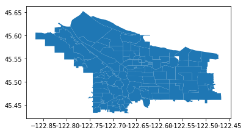

```python
geo_data.plot()
```

#### Choropleth Map

```python
#get max value of calls per neighborhood
geo_crime_data.groupby(['Name']).CallNumber.count().nlargest(1)
```

```
Name
PORTLAND DOWNTOWN    10294
Name: CallNumber, dtype: int64
```

```python
#get min value
geo_crime_data.groupby(['Name']).CallNumber.count().nsmallest(1)
```

```
Name
ARGAY/WILKES COMMUNITY GROUP    2
Name: CallNumber, dtype: int64
```

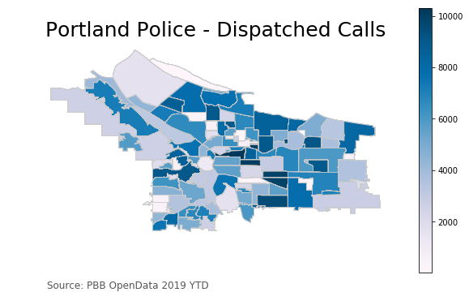

```python
# Set variable to column for measurement value
variable = 'CallNumber'
fig, ax = plt.subplots(1, figsize=(10, 6))
ax.axis('off')
ax.set_title('Portland Police - Dispatched Calls', fontdict={'fontsize': '25', 'fontweight' : '3'})
#min and max value for colorbar
vmin,vmax = 2,10294
#Create colorbar as a legend
sm = plt.cm.ScalarMappable(cmap='PuBu',norm=plt.Normalize(vmin=vmin, vmax=vmax))
sm._A = []
cbar = fig.colorbar(sm)
ax.annotate('Source: PBB OpenData 2019 YTD',xy=(0.1, .08), xycoords='figure fraction', horizontalalignment='left', verticalalignment='top', fontsize=12, color='#555555')
geo_crime_data.plot(column=variable, cmap='PuBu', linewidth=0.8, ax=ax, edgecolor='0.8')
```

### Exporting for Tableau

Our current filesize is way too big right now with over 100,000 Polygon values. To divide this into a more manageable output for Tableau I'll slice off the 'geometry' col for the crime data and filter down to neighborhood 'Name' and 'CallNumber' for a geo data. I'll use the new geo data file to reassemble everything in Tableau along with the original KML file for Polygon info.

```python
# Save filtered data without Polygon info
pdx_crime = geo_crime_data.drop(['geometry'], axis=1)
```

```python
# Save filtered geo data keeping CallNumber for future join
pdx_geo = geo_crime_data[['Name','CallNumber']]
```

```python
# Convert from GeoDataFrame back to DataFrame
pdx_geo = pd.DataFrame(pdx_geo)
```

```python
# Export to csv
pdx_geo.to_csv('pdx_geo.csv')
```

```python
# Convert from GeoDataFrame back to DataFrame
pdx_crime = pd.DataFrame(pdx_crime)
```

```python
# Export to csv
pdx_crime.to_csv('pdx_crime.csv')
```

```python
%%HTML
<div class='tableauPlaceholder' id='viz1574466119657' style='position: relative'><noscript><a href='#'><img alt=' ' src='https:&#47;&#47;public.tableau.com&#47;static&#47;images&#47;Po&#47;PortlandCrimeDashboard2019&#47;PDXPoliceDispatches&#47;1_rss.png' style='border: none' /></a></noscript><object class='tableauViz'  style='display:none;'><param name='host_url' value='https%3A%2F%2Fpublic.tableau.com%2F' /> <param name='embed_code_version' value='3' /> <param name='site_root' value='' /><param name='name' value='PortlandCrimeDashboard2019&#47;PDXPoliceDispatches' /><param name='tabs' value='no' /><param name='toolbar' value='yes' /><param name='static_image' value='https:&#47;&#47;public.tableau.com&#47;static&#47;images&#47;Po&#47;PortlandCrimeDashboard2019&#47;PDXPoliceDispatches&#47;1.png' /> <param name='animate_transition' value='yes' /><param name='display_static_image' value='yes' /><param name='display_spinner' value='yes' /><param name='display_overlay' value='yes' /><param name='display_count' value='yes' /><param name='filter' value='publish=yes' /></object></div>                <script type='text/javascript'>                    var divElement = document.getElementById('viz1574466119657');                    var vizElement = divElement.getElementsByTagName('object')[0];                    if ( divElement.offsetWidth > 800 ) { vizElement.style.width='1000px';vizElement.style.height='827px';} else if ( divElement.offsetWidth > 500 ) { vizElement.style.width='1000px';vizElement.style.height='827px';} else { vizElement.style.width='100%';vizElement.style.height='1627px';}                     var scriptElement = document.createElement('script');                    scriptElement.src = 'https://public.tableau.com/javascripts/api/viz_v1.js';                    vizElement.parentNode.insertBefore(scriptElement, vizElement);                </script>
```

[figure not shown]